# Лабораторная работа №9

Администрирование локальных сетей

Ибрахим Мохсейн Алькамаль

1032225432@rudn.ru

Российский университет дружбы народов

2026-04-11

# Информация

## Докладчик

- Ибрахим Мохсейн Алькамаль
- Российский университет дружбы народов
- [GitHub](https://github.com/Ebrahimalkamal2027)

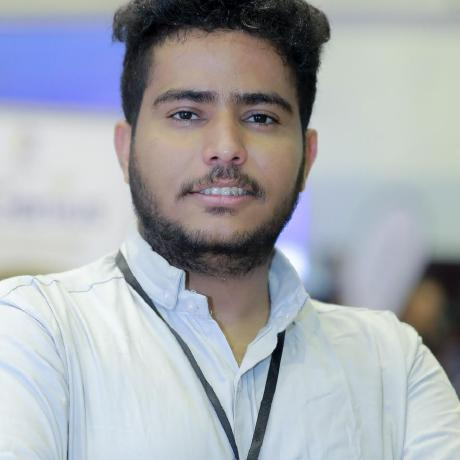

# Цель работы

- Изучение возможностей протокола STP
- Обеспечение отказоустойчивости сети
- Агрегирование интерфейсов
- Перераспределение нагрузки

# Выполнение лабораторной работы

## Формирование резервного соединения

- Замена соединения SW1–SW4 на SW1–SW3
- Интерфейс Gig0/2 на SW3 переведён в trunk
- Соединение SW1–SW4 через Fa0/23 в trunk

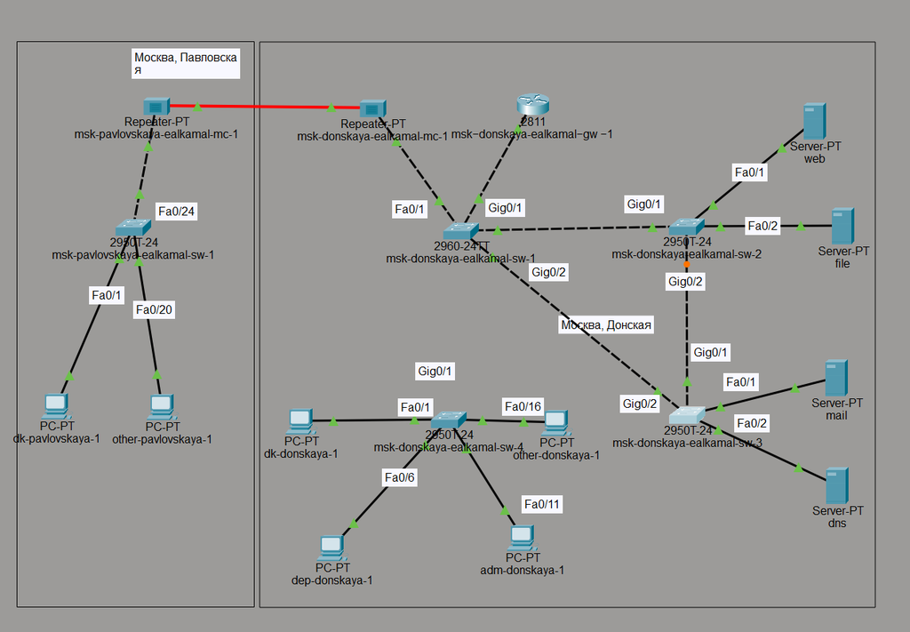

Рисунок 1: Топология сети с резервным соединением

## Настройка транкового режима интерфейса

- Настройка Gig0/2 на SW3
- Использована команда `switchport mode trunk`
- Передача нескольких VLAN по одному каналу

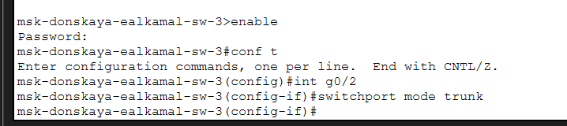

Рисунок 2: Настройка trunk-интерфейса на коммутаторе sw-3

## Настройка транкового соединения между коммутаторами

- Интерфейс Fa0/23 на SW1 переведён в trunk
- Организация соединения между коммутаторами

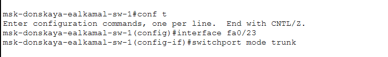

Рисунок 3: Настройка trunk-интерфейса на коммутаторе sw-1

## Настройка транкового интерфейса на втором коммутаторе

- Интерфейс Fa0/23 на SW4 переведён в trunk
- Обеспечена корректная передача VLAN

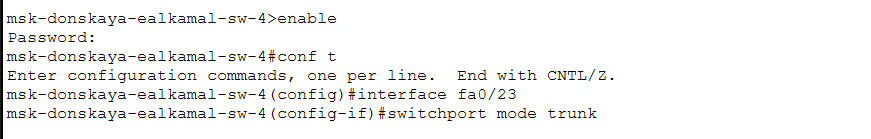

Рисунок 4: Настройка trunk-интерфейса на коммутаторе sw-4

## Анализ движения пакетов ICMP

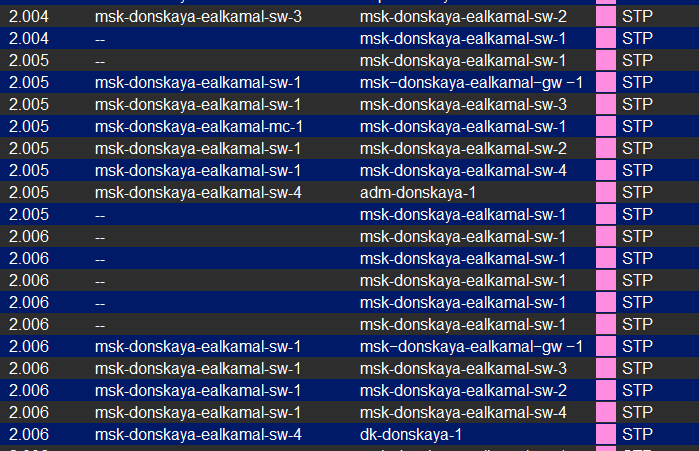

## Дополнительное подтверждение работы STP

- Зафиксирован обмен BPDU
- Подтверждена работа STP
- Наличие резервных путей

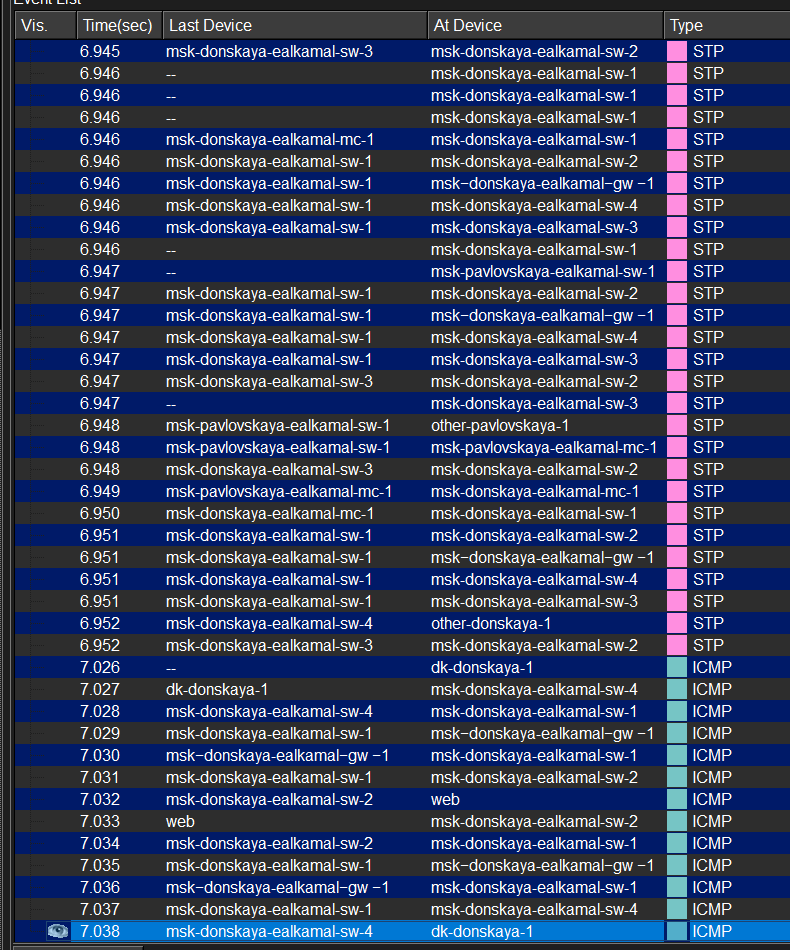

Рисунок 6: Обмен STP BPDU сообщениями

## Проверка состояния протокола STP

- Выполнена команда `show spanning-tree vlan 3`
- Коммутатор не является корневым
- Определён root-порт Gig0/1
- Есть альтернативный заблокированный порт

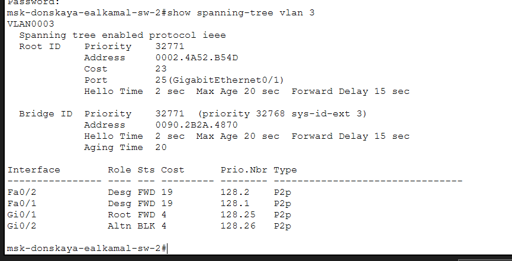

Рисунок 7: Вывод команды show spanning-tree vlan 3

## Назначение корневого коммутатора

- Выполнена команда `spanning-tree vlan 3 root primary`
- SW1 назначен корневым

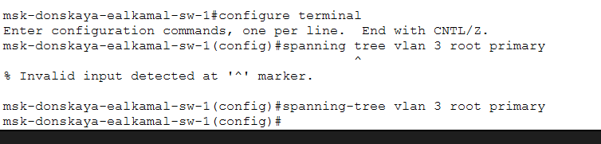

Рисунок 8: Назначение корневого коммутатора STP

## Проверка путей прохождения ICMP-пакетов в режиме симуляции

- Проверен путь к mail через SW1 и SW3
- Проверен путь к web через SW1 и SW2

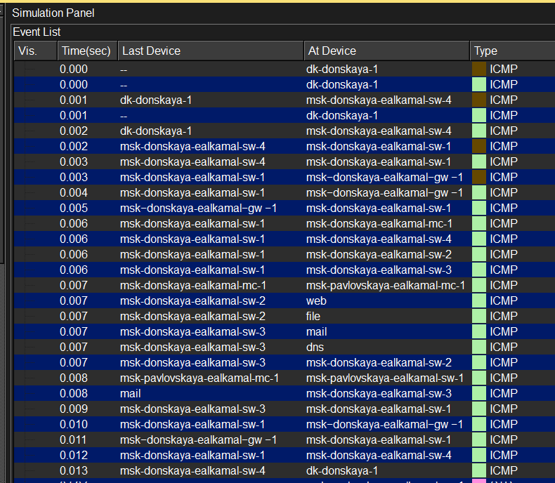

Рисунок 9: Журнал симуляции прохождения ICMP-пакетов к серверам mail и web

- Зафиксирован маршрут до web через SW4 → SW1 → SW2
- Обратный путь подтверждён

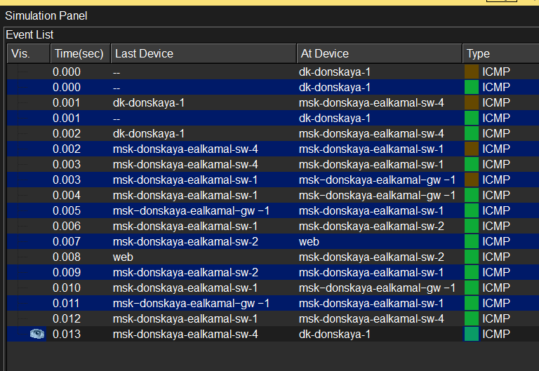

Рисунок 10: Журнал симуляции прохождения ICMP-пакета к серверу web

## Настройка режима PortFast на интерфейсах подключения серверов

- Настройка PortFast на SW2 (Fa0/1, Fa0/2)
- Получено предупреждение о нетранковом режиме

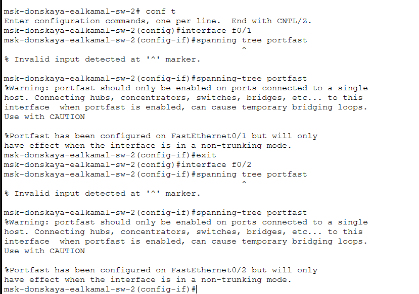

Рисунок 11: Настройка PortFast на интерфейсах коммутатора sw-2

- Настройка PortFast на SW3 (Fa0/2)
- Аналогичное предупреждение

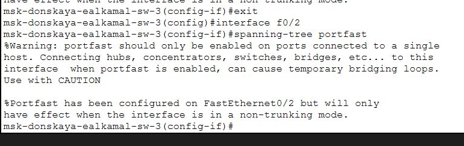

Рисунок 12: Настройка PortFast на интерфейсе коммутатора sw-3

## Исследование отказоустойчивости протокола STP

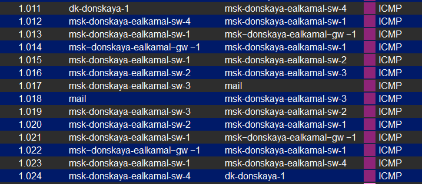

- Зафиксировано перестроение STP
- Восстановление передачи пакетов

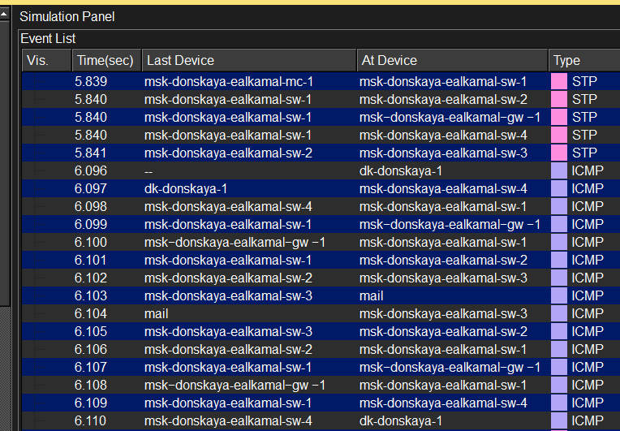

Рисунок 14: Журнал симуляции в момент перестроения STP

- Выполнен ping
- Наблюдаются timeout
- Затем восстановление связи

[figure not shown]

Рисунок 15: Результат команды ping при разрыве основного соединения

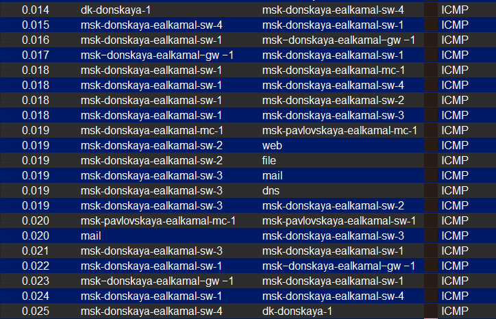

## Исследование отказоустойчивости протокола STP

- Выполнен ping с потерей пакетов
- Восстановление соединения после переключения

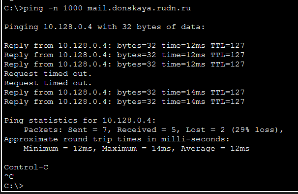

Рисунок 17: Результат команды ping при переключении STP на резервное соединение

## Переключение коммутаторов в режим Rapid PVST+

- Зафиксирован маршрут ICMP после переключения
- Путь проходит через SW4 → SW1 → SW2 → SW3

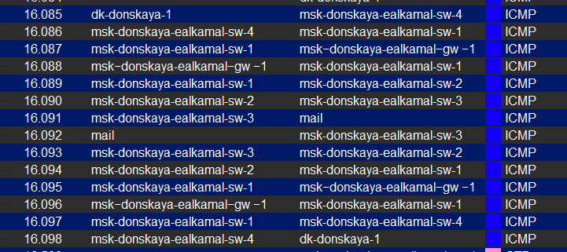

Рисунок 18: Журнал симуляции прохождения ICMP-пакета после переключения на Rapid PVST+

## Исследование отказоустойчивости протокола Rapid PVST+

- Используется резервный путь
- Подтверждена работа Rapid PVST+

[figure not shown]

Рисунок 19: Журнал симуляции использования резервного пути в режиме Rapid PVST+

## Формирование агрегированного соединения между msk-donskaya-sw-1 и msk-donskaya-sw-4

- Соединение по интерфейсам Fa0/20–Fa0/23
- Четыре параллельных канала

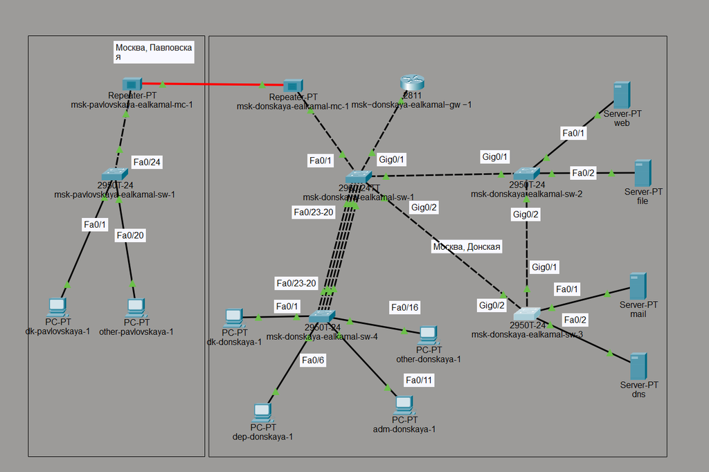

Рисунок 20: Логическая топология сети с агрегированным соединением между sw-1 и sw-4

## Настройка агрегирования каналов EtherChannel

- Настроен channel-group 1
- Создан интерфейс Port-channel 1
- Обнаружена несовместимость Fa0/23

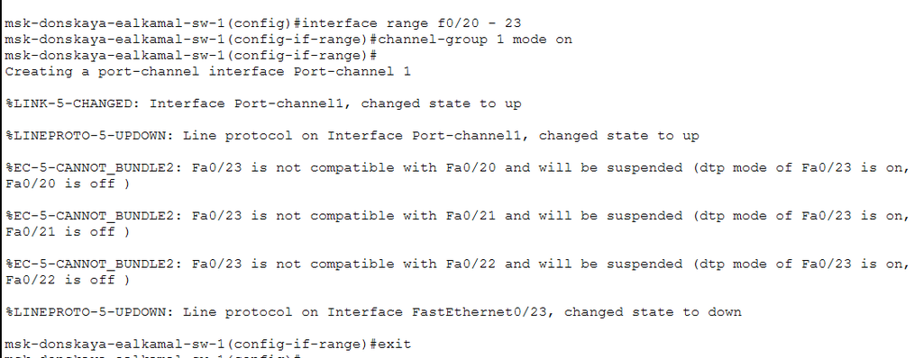

Рисунок 21: Вывод CLI при настройке EtherChannel на коммутаторе sw-1

## CLI при настройке EtherChannel на коммутаторе sw-4

- Удалён access vlan 104 на SW4
- Настроен EtherChannel
- Зафиксированы ошибки Native VLAN
- Блокировка Port-channel1

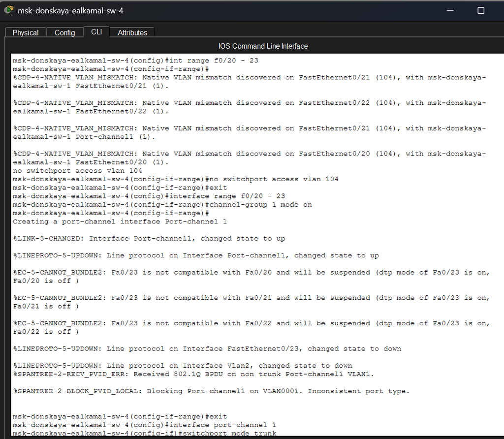

Рисунок 22: Вывод CLI при настройке EtherChannel на коммутаторе sw-4

# Выводы

## Выводы

- Сформировано резервное соединение
- STP обеспечивает отказоустойчивость
- Наблюдается временная потеря пакетов
- Связь восстанавливается через резервный путь
- Rapid PVST+ ускоряет восстановление
- Передача ICMP стабильна
- Обнаружены ошибки EtherChannel
- Несоответствие VLAN и DTP
- Частичное исключение портов
- Требуется корректная настройка STP и EtherChannel